# A GDP egy főre és a vállalkozásindítás időigénye közötti kapcsolat

Házi feladat elemzés

2025-11-18

# Bevezetés

Ez az elemzés az országok jövedelemtermelése (egy főre jutó GDP, PPP) és a vállalkozásindítás könnyedsége (a szükséges napokban mérve) közötti kapcsolatot vizsgálja. Különböző funkcionális formákat fogunk megvizsgálni, és kezelni fogjuk a szélsőséges értékeket, hogy megtaláljuk a legjobb regressziós modellt.

**Megjegyzés:** A Világbank Doing Business projektjét 2021 szeptemberében megszüntették. Azonban a történeti adatok továbbra is elérhetők a Doing Business adatbázison keresztül (source=14) a Világbank API-ban. 2019-es adatokat használunk (a legfrissebb elérhető év), hogy valódi keresztmetszeti elemzést biztosítsunk, ahogy a feladat megköveteli.

# 1. Adatgyűjtés

```r
# CRAN tükör beállítása
options(repos = c(CRAN = "https://cloud.r-project.org"))

# Csomagok telepítése szükség esetén
if (!require("WDI")) install.packages("WDI")
if (!require("tidyverse")) install.packages("tidyverse")
if (!require("car")) install.packages("car")
if (!require("MASS")) install.packages("MASS")
if (!require("broom")) install.packages("broom")
if (!require("knitr")) install.packages("knitr")
if (!require("kableExtra")) install.packages("kableExtra")
if (!require("jsonlite")) install.packages("jsonlite")

library(WDI)
library(tidyverse)
library(car)
library(MASS)
library(broom)
library(knitr)
library(kableExtra)
library(jsonlite)
```

```r
# Indikátorok keresése
# Egy főre jutó GDP, PPP (állandó 2021 nemzetközi $): NY.GDP.PCAP.PP.KD
# Vállalkozásindításhoz szükséges idő (napok): IC.REG.DURS (Doing Business adatbázisból, source=14)

# GDP adatok letöltése WDI-vel csak 2019-re (keresztmetszeti)
gdp_data <- WDI(indicator = "NY.GDP.PCAP.PP.KD",
                start = 2019, end = 2019, extra = TRUE)

# Egyedi függvény a Doing Business adatok közvetlen lekérdezéséhez az API-ból source=14 paraméterrel
# (A WDI csomag nem támogatja az archivált DB adatokhoz szükséges source paramétert)
fetch_db_data <- function(indicator, start_year, end_year) {
  url <- paste0(
    "https://api.worldbank.org/v2/country/all/indicator/", indicator,
    "?source=14&format=json&per_page=20000&date=", start_year, ":", end_year
  )

  cat("Adatok lekérése innen:", url, "\n")
  data_json <- fromJSON(url)
  data_df <- data_json[[2]]

  # Kinyerés és tisztítás
  result <- data.frame(
    country = data_df$country$value,
    iso3c = data_df$countryiso3code,
    year = as.numeric(data_df$date),
    value = as.numeric(data_df$value)
  )

  return(result)
}

# Vállalkozásindítási idő adatok lekérése a Doing Business adatbázisból
cat("Vállalkozásindítási idő adatok letöltése a Doing Business archívumból...\n")
```

```
## Vállalkozásindítási idő adatok letöltése a Doing Business archívumból...
```

```r
business_data <- fetch_db_data("IC.REG.DURS", 2019, 2019)
```

```
## Adatok lekérése innen: https://api.worldbank.org/v2/country/all/indicator/IC.REG.DURS?source=14&format=json&per_page=20000&date=2019:2019
```

```r
# Adatkészletek egyesítése
data_raw <- gdp_data %>%
  dplyr::select(country, iso3c, year, gdp_ppp = NY.GDP.PCAP.PP.KD, region, income) %>%
  inner_join(
    business_data %>%
      rename(time_business = value) %>%
      dplyr::select(iso3c, year, time_business),
    by = c("iso3c", "year")
  )

# Aggregátumok eltávolítása (csak egyedi országok megtartása)
# Azok a sorok szűrése, ahol a régió "Aggregates" vagy a jövedelem "Aggregates"
# Ez valódi keresztmetszeti adatkészletet hoz létre ország szerinti egy megfigyeléssel
data_clean <- data_raw %>%
  filter(region != "Aggregates",
         !is.na(gdp_ppp),
         !is.na(time_business),
         time_business > 0,  # Nulla vagy negatív értékek eltávolítása
         gdp_ppp > 0)

# Összefoglaló megjelenítése
cat("\nAdatok összefoglalója:\n")
```

```
##
## Adatok összefoglalója:
```

```r
cat("Országok száma:", nrow(data_clean), "\n")
```

```
## Országok száma: 182
```

```r
cat("Év:", unique(data_clean$year), "\n\n")
```

```
## Év: 2019
```

```r
# Az első néhány megfigyelés megjelenítése
kable(head(data_clean, 10),
      caption = "Az első 10 megfigyelés az adatkészletből") %>%
  kable_styling(bootstrap_options = c("striped", "hover", "condensed"))
```

Az első 10 megfigyelés az adatkészletből

| country | iso3c | year | gdp_ppp | region | income | time_business |
| --- | --- | --- | --- | --- | --- | --- |
| Afghanistan | AFG | 2019 | 2927.245 | South Asia | Low income | 8.5 |
| Albania | ALB | 2019 | 15079.374 | Europe & Central Asia | Upper middle income | 4.5 |
| Algeria | DZA | 2019 | 15199.199 | Middle East & North Africa | Upper middle income | 18.0 |
| Angola | AGO | 2019 | 8274.543 | Sub-Saharan Africa | Lower middle income | 36.0 |
| Antigua and Barbuda | ATG | 2019 | 29651.864 | Latin America & Caribbean | High income | 19.0 |
| Argentina | ARG | 2019 | 26629.553 | Latin America & Caribbean | Upper middle income | 11.5 |
| Armenia | ARM | 2019 | 16215.361 | Europe & Central Asia | Upper middle income | 4.0 |
| Australia | AUS | 2019 | 57837.061 | East Asia & Pacific | High income | 2.0 |
| Austria | AUT | 2019 | 64688.144 | Europe & Central Asia | High income | 21.0 |
| Azerbaijan | AZE | 2019 | 20101.492 | Europe & Central Asia | Upper middle income | 3.5 |

**Miért ez a megközelítés?** A WDI csomagot használjuk a GDP adatokhoz, és közvetlenül elérjük a Doing Business adatbázist (source=14) a Világbank API-n keresztül a vállalkozásindítási idő adatokhoz. 2019-es adatokat használunk (a legfrissebb elérhető év), hogy valódi keresztmetszeti adatkészletet hozzunk létre ország szerinti egy megfigyeléssel. Csak az egyedi országokra szűrünk (kizárva a regionális/jövedelmi aggregátumokat). Ez a megközelítés összhangban van a feladat követelményeivel, és biztosítja, hogy a megfigyelések függetlenek legyenek.

# 2. Feltáró adatelemzés

```r
# Összefoglaló statisztikák
summary_stats <- data_clean %>%
  dplyr::select(gdp_ppp, time_business) %>%
  summary()

print(summary_stats)
```

```
##     gdp_ppp         time_business
##  Min.   :   855.7   Min.   :  0.50
##  1st Qu.:  6106.3   1st Qu.:  7.00
##  Median : 15561.6   Median : 12.00
##  Mean   : 24348.6   Mean   : 17.80
##  3rd Qu.: 35187.5   3rd Qu.: 19.88
##  Max.   :132724.8   Max.   :173.00
```

```r
# Részletes statisztikák
data_clean %>%
  dplyr::select(gdp_ppp, time_business) %>%
  summarise(
    across(everything(),
           list(mean = mean,
                sd = sd,
                min = min,
                q25 = ~quantile(., 0.25),
                median = median,
                q75 = ~quantile(., 0.75),
                max = max,
                n = ~sum(!is.na(.))),
           .names = "{.col}_{.fn}")
  ) %>%
  pivot_longer(everything()) %>%
  separate(name, into = c("variable", "statistic"), sep = "_(?=[^_]+$)") %>%
  pivot_wider(names_from = statistic, values_from = value) %>%
  kable(caption = "Részletes összefoglaló statisztikák", digits = 2) %>%
  kable_styling(bootstrap_options = c("striped", "hover"))
```

Részletes összefoglaló statisztikák

| variable | mean | sd | min | q25 | median | q75 | max | n |
| --- | --- | --- | --- | --- | --- | --- | --- | --- |
| gdp_ppp | 24348.56 | 24515.29 | 855.73 | 6106.25 | 15561.55 | 35187.52 | 132724.8 | 182 |
| time_business | 17.80 | 19.93 | 0.50 | 7.00 | 12.00 | 19.88 | 173.0 | 182 |

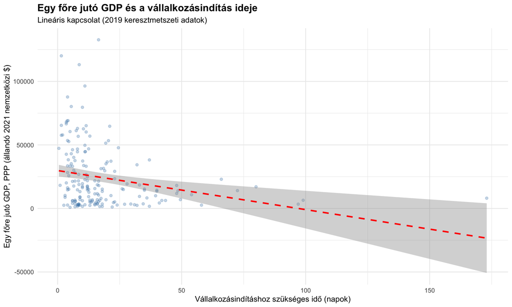

```r
# Alapvető szórásdiagram
ggplot(data_clean, aes(x = time_business, y = gdp_ppp)) +
  geom_point(alpha = 0.3, size = 1.5, color = "steelblue") +
  geom_smooth(method = "lm", se = TRUE, color = "red", linetype = "dashed") +
  labs(title = "Egy főre jutó GDP és a vállalkozásindítás ideje",
       subtitle = "Lineáris kapcsolat (2019 keresztmetszeti adatok)",
       x = "Vállalkozásindításhoz szükséges idő (napok)",
       y = "Egy főre jutó GDP, PPP (állandó 2021 nemzetközi $)") +
  theme_minimal() +
  theme(plot.title = element_text(face = "bold", size = 14))
```

**Megfigyelés:** A szórásdiagram általában negatív kapcsolatot mutat (több idő → alacsonyabb GDP), ami gazdasági szempontból értelmes. A vállalkozásalapítás bürokratikus akadályainak korrelálniuk kellene az alacsonyabb gazdasági teljesítménnyel. Jelentős szórás tapasztalható, és potenciális kiugró értékek is vannak nagyon magas indítási idővel. A kapcsolat nem lineárisnak tűnik.

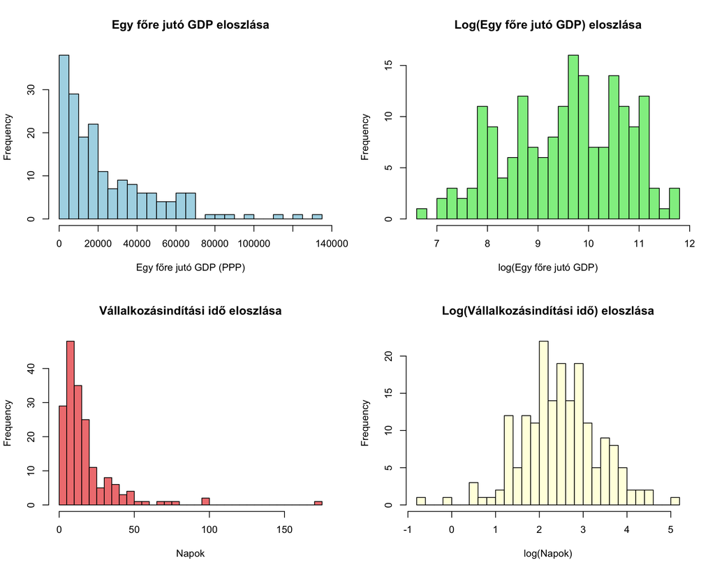

```r
# Eloszlási grafikonok
par(mfrow = c(2, 2))

# GDP hisztogramja
hist(data_clean$gdp_ppp, breaks = 30, col = "lightblue",
     main = "Egy főre jutó GDP eloszlása", xlab = "Egy főre jutó GDP (PPP)")

# Log GDP hisztogramja
hist(log(data_clean$gdp_ppp), breaks = 30, col = "lightgreen",
     main = "Log(Egy főre jutó GDP) eloszlása", xlab = "log(Egy főre jutó GDP)")

# Vállalkozásindítási idő hisztogramja
hist(data_clean$time_business, breaks = 30, col = "lightcoral",
     main = "Vállalkozásindítási idő eloszlása", xlab = "Napok")

# Log vállalkozásindítási idő hisztogramja
hist(log(data_clean$time_business), breaks = 30, col = "lightyellow",
     main = "Log(Vállalkozásindítási idő) eloszlása", xlab = "log(Napok)")
```

**Miért ellenőrizzük az eloszlásokat?** A változók eloszlásának megértése segít eldönteni a megfelelő transzformációkat. Mindkét változó jobbra ferdültnek tűnik, ami azt sugallja, hogy logaritmikus transzformációk megfelelőek lehetnek. Ez gyakori a gazdasági adatoknál, ahol a százalékos változások értelmesebek, mint az abszolút változások.

# 3. Különböző funkcionális formák tesztelése

Négy különböző funkcionális formát fogunk tesztelni: 1. Lineáris: $y = \beta_0 + \beta_1 x$ 2. Log-Log: $\log(y) = \beta_0 + \beta_1 \log(x)$ 3. Log-Lineáris: $\log(y) = \beta_0 + \beta_1 x$ 4. Lineáris-Log: $y = \beta_0 + \beta_1 \log(x)$

```r
# 1. modell: Lineáris
model_linear <- lm(gdp_ppp ~ time_business, data = data_clean)

# 2. modell: Log-Log
model_loglog <- lm(log(gdp_ppp) ~ log(time_business), data = data_clean)

# 3. modell: Log-Lineáris
model_loglin <- lm(log(gdp_ppp) ~ time_business, data = data_clean)

# 4. modell: Lineáris-Log
model_linlog <- lm(gdp_ppp ~ log(time_business), data = data_clean)

# Modellek összehasonlítása
comparison <- data.frame(
  Modell = c("Lineáris", "Log-Log", "Log-Lineáris", "Lineáris-Log"),
  R_négyzet = c(summary(model_linear)$r.squared,
                summary(model_loglog)$r.squared,
                summary(model_loglin)$r.squared,
                summary(model_linlog)$r.squared),
  Korrigált_R_négyzet = c(summary(model_linear)$adj.r.squared,
                          summary(model_loglog)$adj.r.squared,
                          summary(model_loglin)$adj.r.squared,
                          summary(model_linlog)$adj.r.squared),
  AIC = c(AIC(model_linear),
          NA,  # AIC nem közvetlenül összehasonlítható különböző függő változókra
          NA,
          AIC(model_linlog)),
  RMSE = c(sqrt(mean(residuals(model_linear)^2)),
           sqrt(mean(residuals(model_loglog)^2)),
           sqrt(mean(residuals(model_loglin)^2)),
           sqrt(mean(residuals(model_linlog)^2)))
)

kable(comparison, digits = 3,
      caption = "Funkcionális formák összehasonlítása") %>%
  kable_styling(bootstrap_options = c("striped", "hover"))
```

Funkcionális formák összehasonlítása

| Modell | R_négyzet | Korrigált_R_négyzet | AIC | RMSE |
| --- | --- | --- | --- | --- |
| Lineáris | 0.062 | 0.057 | 4188.725 | 23672.367 |
| Log-Log | 0.086 | 0.081 | NA | 1.081 |
| Log-Lineáris | 0.041 | 0.036 | NA | 1.107 |
| Lineáris-Log | 0.125 | 0.120 | 4176.127 | 22867.102 |

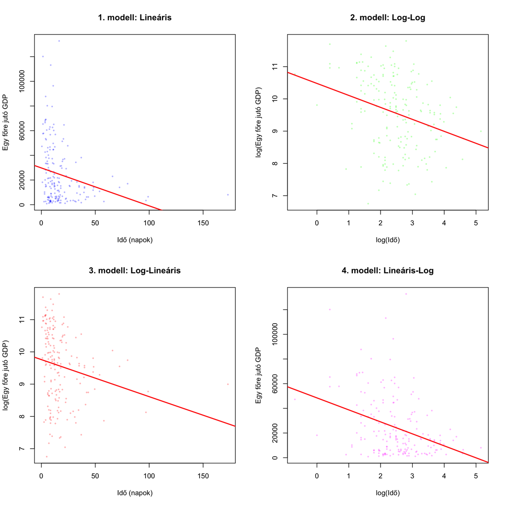

```r
# Mind a négy modell vizualizációja
par(mfrow = c(2, 2))

# 1. modell: Lineáris
plot(data_clean$time_business, data_clean$gdp_ppp,
     main = "1. modell: Lineáris", xlab = "Idő (napok)", ylab = "Egy főre jutó GDP",
     pch = 16, col = rgb(0, 0, 1, 0.3), cex = 0.5)
abline(model_linear, col = "red", lwd = 2)

# 2. modell: Log-Log
plot(log(data_clean$time_business), log(data_clean$gdp_ppp),
     main = "2. modell: Log-Log", xlab = "log(Idő)", ylab = "log(Egy főre jutó GDP)",
     pch = 16, col = rgb(0, 1, 0, 0.3), cex = 0.5)
abline(model_loglog, col = "red", lwd = 2)

# 3. modell: Log-Lineáris
plot(data_clean$time_business, log(data_clean$gdp_ppp),
     main = "3. modell: Log-Lineáris", xlab = "Idő (napok)", ylab = "log(Egy főre jutó GDP)",
     pch = 16, col = rgb(1, 0, 0, 0.3), cex = 0.5)
abline(model_loglin, col = "red", lwd = 2)

# 4. modell: Lineáris-Log
plot(log(data_clean$time_business), data_clean$gdp_ppp,
     main = "4. modell: Lineáris-Log", xlab = "log(Idő)", ylab = "Egy főre jutó GDP",
     pch = 16, col = rgb(1, 0, 1, 0.3), cex = 0.5)
abline(model_linlog, col = "red", lwd = 2)
```

**Miért tesztelünk több formát?** A gazdasági kapcsolatok ritkán lineárisak. A log-log forma különösen hasznos, mivel állandó rugalmassági interpretációt biztosít. A vizuális vizsgálat azt sugallja, hogy a logaritmikus transzformációk javítják az illeszkedést.

# 4. Diagnosztikai elemzés: Szélsőséges értékek és tőkeáttétel

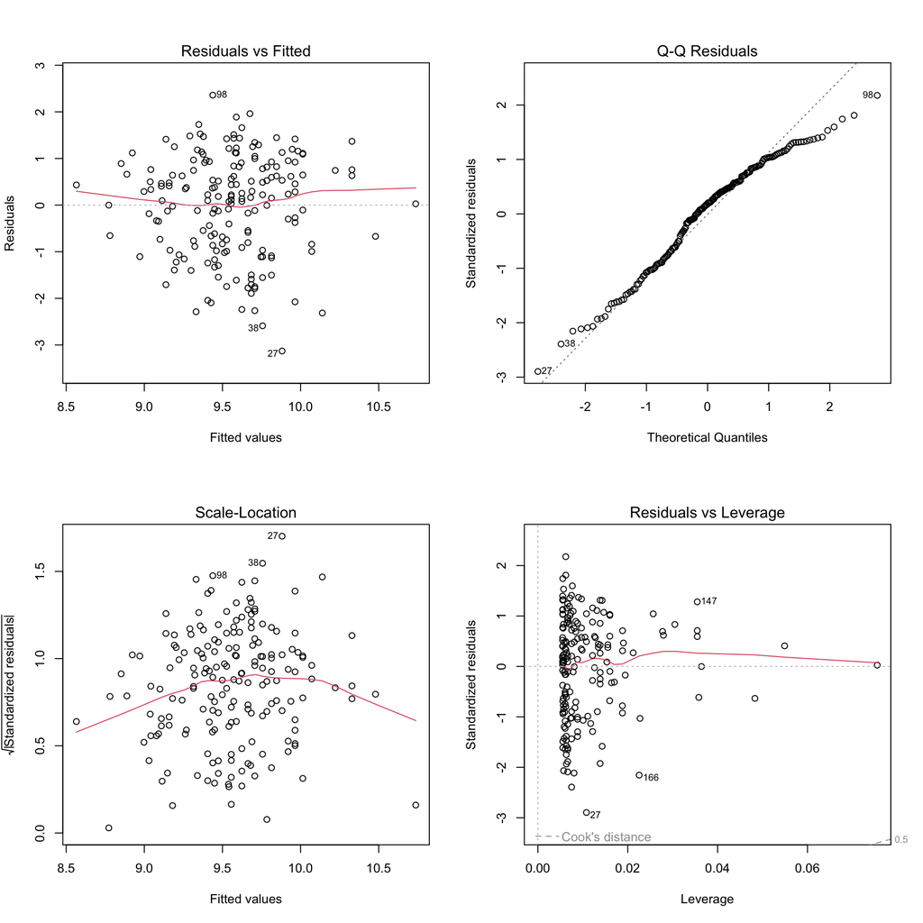

```r
# Diagnosztikai grafikonok a log-log modellhez
par(mfrow = c(2, 2))
plot(model_loglog)
```

```r
# Befolyási mutatók számítása
influence_data <- data_clean %>%
  mutate(
    log_gdp = log(gdp_ppp),
    log_time = log(time_business),
    residuals = residuals(model_loglog),
    studentized_resid = rstudent(model_loglog),
    cooks_d = cooks.distance(model_loglog),
    leverage = hatvalues(model_loglog),
    dffits_val = dffits(model_loglog)
  )

# Befolyásos megfigyelések azonosítása több kritérium alapján
influential <- influence_data %>%
  mutate(
    high_leverage = leverage > 2 * 2 / nrow(data_clean),  # 2p/n küszöb
    high_cooks = cooks_d > 4 / nrow(data_clean),  # 4/n küszöb
    outlier_resid = abs(studentized_resid) > 2.5,
    high_dffits = abs(dffits_val) > 2 * sqrt(2 / nrow(data_clean))
  ) %>%
  filter(high_leverage | high_cooks | outlier_resid | high_dffits)

cat("Potenciálisan befolyásos megfigyelések száma:", nrow(influential), "\n\n")
```

```
## Potenciálisan befolyásos megfigyelések száma: 17
```

```r
if(nrow(influential) > 0) {
  influential %>%
    dplyr::select(country, year, time_business, gdp_ppp, cooks_d, leverage,
           studentized_resid, high_leverage, high_cooks, outlier_resid) %>%
    arrange(desc(cooks_d)) %>%
    kable(digits = 3, caption = "Befolyásos megfigyelések") %>%
    kable_styling(bootstrap_options = c("striped", "hover", "condensed"))
}
```

Befolyásos megfigyelések

| country | year | time_business | gdp_ppp | cooks_d | leverage | studentized_resid | high_leverage | high_cooks | outlier_resid |
| --- | --- | --- | --- | --- | --- | --- | --- | --- | --- |
| Togo | 2019 | 2.5 | 2501.031 | 0.054 | 0.023 | -2.177 | TRUE | TRUE | FALSE |
| Burundi | 2019 | 5.0 | 855.733 | 0.046 | 0.011 | -2.958 | FALSE | TRUE | TRUE |
| Singapore | 2019 | 1.5 | 120114.134 | 0.030 | 0.035 | 1.284 | TRUE | TRUE | FALSE |
| Rwanda | 2019 | 4.0 | 2667.465 | 0.026 | 0.014 | -1.938 | FALSE | TRUE | FALSE |
| Congo, Dem. Rep. | 2019 | 7.0 | 1296.948 | 0.022 | 0.008 | -2.424 | FALSE | FALSE | FALSE |
| Suriname | 2019 | 66.0 | 22966.741 | 0.014 | 0.026 | 1.043 | TRUE | FALSE | FALSE |
| Chad | 2019 | 58.0 | 2604.916 | 0.012 | 0.023 | -1.030 | TRUE | FALSE | FALSE |
| Bosnia and Herzegovina | 2019 | 80.0 | 17029.621 | 0.011 | 0.030 | 0.832 | TRUE | FALSE | FALSE |
| Georgia | 2019 | 1.0 | 18186.882 | 0.010 | 0.048 | -0.632 | TRUE | FALSE | FALSE |
| Hong Kong SAR, China | 2019 | 1.5 | 65388.331 | 0.009 | 0.035 | 0.710 | TRUE | FALSE | FALSE |
| Haiti | 2019 | 97.0 | 3381.585 | 0.007 | 0.036 | -0.612 | TRUE | FALSE | FALSE |
| Australia | 2019 | 2.0 | 57837.061 | 0.007 | 0.028 | 0.693 | TRUE | FALSE | FALSE |
| Canada | 2019 | 1.5 | 57583.846 | 0.006 | 0.035 | 0.591 | TRUE | FALSE | FALSE |
| Iran, Islamic Rep. | 2019 | 72.5 | 14040.665 | 0.005 | 0.028 | 0.616 | TRUE | FALSE | FALSE |
| Lao PDR | 2019 | 173.0 | 8075.275 | 0.005 | 0.055 | 0.407 | TRUE | FALSE | FALSE |
| New Zealand | 2019 | 0.5 | 47277.663 | 0.000 | 0.076 | 0.026 | TRUE | FALSE | FALSE |
| Cambodia | 2019 | 99.0 | 6448.885 | 0.000 | 0.036 | -0.001 | TRUE | FALSE | FALSE |

```r
# Befolyási ábra
influencePlot(model_loglog, main = "Befolyási ábra (Log-Log modell)",
              sub = "A kör mérete arányos a Cook-távolsággal")
```

```
##         StudRes         Hat        CookD
## 27  -2.95777306 0.010803371 4.580075e-02
## 38  -2.42384923 0.007504877 2.162672e-02
## 91   0.40740914 0.054914371 4.844661e-03
## 119  0.02555304 0.075531157 2.682296e-05
## 166 -2.17701716 0.022549356 5.355540e-02
```

```r
# Országnevek hozzáadása a befolyásos pontokhoz
influential_indices <- which(influence_data$cooks_d > 4/nrow(data_clean) |
                             abs(influence_data$studentized_resid) > 2.5)
if(length(influential_indices) > 0) {
  text(influence_data$leverage[influential_indices],
       influence_data$studentized_resid[influential_indices],
       labels = data_clean$country[influential_indices],
       pos = 4, cex = 0.7, col = "red")
}
```

[figure not shown]

**Miért vizsgáljuk a befolyást?** A magas tőkeáttételű pontok és a kiugró értékek aránytalanul befolyásolhatják a regressziós eredményeket. Meg kell vizsgálnunk, hogy ezek a megfigyelések jogos adatpontok-e vagy hibák, és döntenünk kell a kezelésükről.

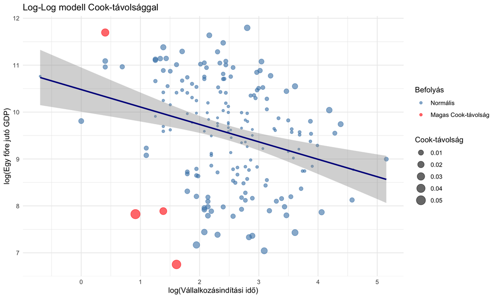

```r
# Buborékdiagram a Cook-távolsággal
ggplot(influence_data, aes(x = log_time, y = log_gdp)) +
  geom_point(aes(size = cooks_d, color = cooks_d > 4/nrow(data_clean)), alpha = 0.6) +
  geom_smooth(method = "lm", se = TRUE, color = "darkblue") +
  scale_color_manual(values = c("steelblue", "red"),
                     labels = c("Normális", "Magas Cook-távolság")) +
  labs(title = "Log-Log modell Cook-távolsággal",
       x = "log(Vállalkozásindítási idő)",
       y = "log(Egy főre jutó GDP)",
       size = "Cook-távolság",
       color = "Befolyás") +
  theme_minimal()
```

# 5. Modell-összehasonlítás: Befolyásos pontokkal és anélkül

```r
# Valóban problémás befolyásos pontok azonosítása
# Kombinált kritériumok használata: magas Cook-távolság ÉS (magas tőkeáttétel VAGY kiugró érték)
problematic <- influence_data %>%
  filter(cooks_d > 4/nrow(data_clean) & (leverage > 2*2/nrow(data_clean) | abs(studentized_resid) > 2.5))

cat("Befolyási kritériumok alapján eltávolított megfigyelések:", nrow(problematic), "\n")
```

```
## Befolyási kritériumok alapján eltávolított megfigyelések: 3
```

```r
if(nrow(problematic) > 0) {
  print(problematic %>% dplyr::select(country, year, time_business, gdp_ppp, cooks_d, leverage, studentized_resid))
}
```

```
##     country year time_business     gdp_ppp    cooks_d   leverage
## 1   Burundi 2019           5.0    855.7327 0.04580075 0.01080337
## 2 Singapore 2019           1.5 120114.1339 0.03018876 0.03547228
## 3      Togo 2019           2.5   2501.0309 0.05355540 0.02254936
##   studentized_resid
## 1         -2.957773
## 2          1.283602
## 3         -2.177017
```

```r
# Modell illesztése a problémás megfigyelések nélkül
if(nrow(problematic) > 0) {
  data_robust <- influence_data %>%
    filter(!(country %in% problematic$country))
} else {
  data_robust <- influence_data
}

model_loglog_robust <- lm(log_gdp ~ log_time, data = data_robust)

# Robusztus regresszió kipróbálása alternatívaként
model_robust_regression <- rlm(log_gdp ~ log_time, data = influence_data)

# Minden log-log specifikáció összehasonlítása
comparison_detailed <- data.frame(
  Modell = c("Log-Log (Teljes)", "Log-Log (Kiugró értékek eltávolítva)", "Robusztus regresszió"),
  N = c(nrow(data_clean), nrow(data_robust), nrow(data_clean)),
  R_négyzet = c(summary(model_loglog)$r.squared,
                summary(model_loglog_robust)$r.squared,
                NA),
  Korrigált_R_négyzet = c(summary(model_loglog)$adj.r.squared,
                          summary(model_loglog_robust)$adj.r.squared,
                          NA),
  Együttható_Tengelymetszet = c(coef(model_loglog)[1],
                                 coef(model_loglog_robust)[1],
                                 coef(model_robust_regression)[1]),
  Együttható_Meredekség = c(coef(model_loglog)[2],
                             coef(model_loglog_robust)[2],
                             coef(model_robust_regression)[2]),
  RMSE = c(sqrt(mean(residuals(model_loglog)^2)),
           sqrt(mean(residuals(model_loglog_robust)^2)),
           sqrt(mean(residuals(model_robust_regression)^2)))
)

kable(comparison_detailed, digits = 4,
      caption = "Log-Log modell specifikációk összehasonlítása") %>%
  kable_styling(bootstrap_options = c("striped", "hover"))
```

Log-Log modell specifikációk összehasonlítása

| Modell | N | R_négyzet | Korrigált_R_négyzet | Együttható_Tengelymetszet | Együttható_Meredekség | RMSE |
| --- | --- | --- | --- | --- | --- | --- |
| Log-Log (Teljes) | 182 | 0.0856 | 0.0805 | 10.4795 | -0.3715 | 1.0806 |
| Log-Log (Kiugró értékek eltávolítva) | 179 | 0.0997 | 0.0946 | 10.5690 | -0.3981 | 1.0445 |
| Robusztus regresszió | 182 | NA | NA | 10.5693 | -0.3948 | 1.0812 |

**Döntési indoklás:** Három megközelítést hasonlítunk össze: 1. Teljes adatkészlet 2. Nagyon befolyásos pontokkal eltávolított adatkészlet 3. Robusztus regresszió (automatikusan csökkenti a kiugró értékek súlyát)

A robusztus megközelítés segít megvizsgálni, hogy következtetéseinket néhány szélsőséges megfigyelés határozza-e meg.

# 6. Végső modellválasztás és értelmezés

```r
# Végső modell kiválasztása (robusztus megközelítéssel a valóban problémás pontok eltávolítására)
final_model <- model_loglog_robust

# Részletes összefoglaló
summary_final <- summary(final_model)
print(summary_final)
```

```
##
## Call:
## lm(formula = log_gdp ~ log_time, data = data_robust)
##
## Residuals:
##     Min      1Q  Median      3Q     Max
## -2.6267 -0.8436  0.1833  0.7875  2.3429
##
## Coefficients:
##             Estimate Std. Error t value Pr(>|t|)
## (Intercept) 10.56902    0.23890  44.241  < 2e-16 ***
## log_time    -0.39806    0.08991  -4.427 1.67e-05 ***
## ---
## Signif. codes:  0 '***' 0.001 '**' 0.01 '*' 0.05 '.' 0.1 ' ' 1
##
## Residual standard error: 1.05 on 177 degrees of freedom
## Multiple R-squared:  0.0997, Adjusted R-squared:  0.09461
## F-statistic:  19.6 on 1 and 177 DF,  p-value: 1.666e-05
```

```r
# Konfidencia intervallumok
conf_int <- confint(final_model)
kable(conf_int, digits = 4,
      caption = "95%-os konfidencia intervallumok az együtthatókhoz") %>%
  kable_styling(bootstrap_options = c("striped", "hover"))
```

95%-os konfidencia intervallumok az együtthatókhoz

|  | 2.5 % | 97.5 % |
| --- | --- | --- |
| (Intercept) | 10.0976 | 11.0405 |
| log_time | -0.5755 | -0.2206 |

```r
# Rendezett kimenet
tidy_final <- tidy(final_model, conf.int = TRUE)
kable(tidy_final, digits = 4,
      caption = "Végső modell együtthatói") %>%
  kable_styling(bootstrap_options = c("striped", "hover"))
```

Végső modell együtthatói

| term | estimate | std.error | statistic | p.value | conf.low | conf.high |
| --- | --- | --- | --- | --- | --- | --- |
| (Intercept) | 10.5690 | 0.2389 | 44.2407 | 0 | 10.0976 | 11.0405 |
| log_time | -0.3981 | 0.0899 | -4.4273 | 0 | -0.5755 | -0.2206 |

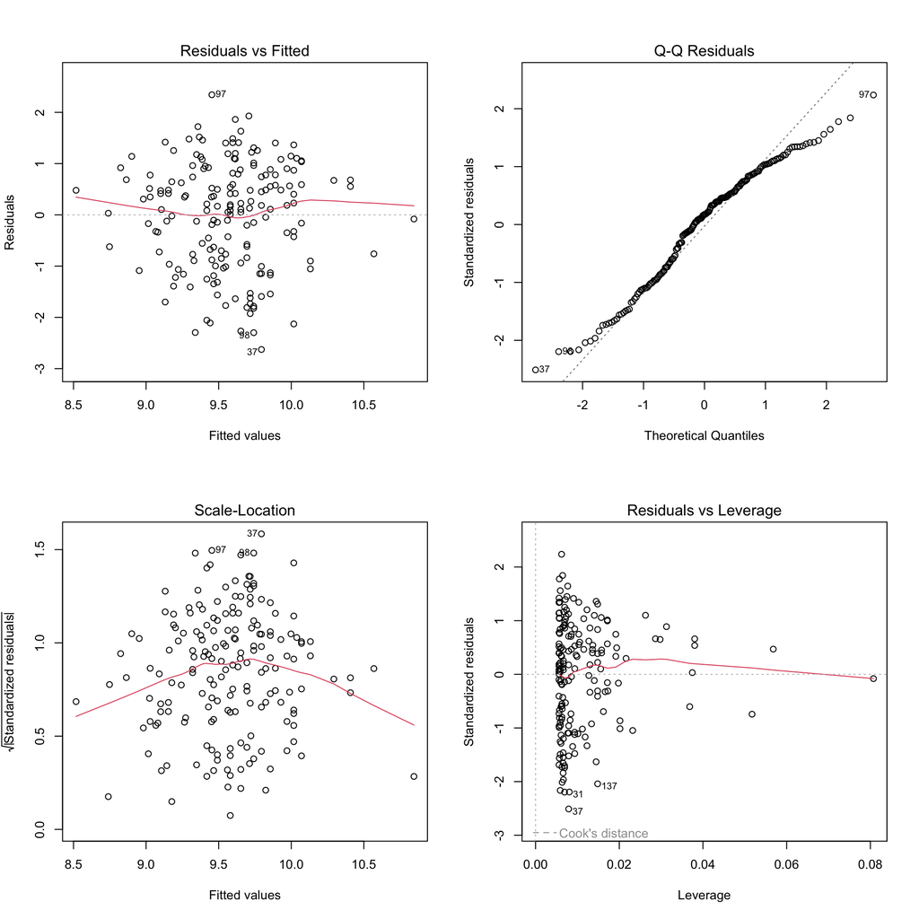

```r
# Diagnosztikai grafikonok a végső modellhez
par(mfrow = c(2, 2))
plot(final_model)
```

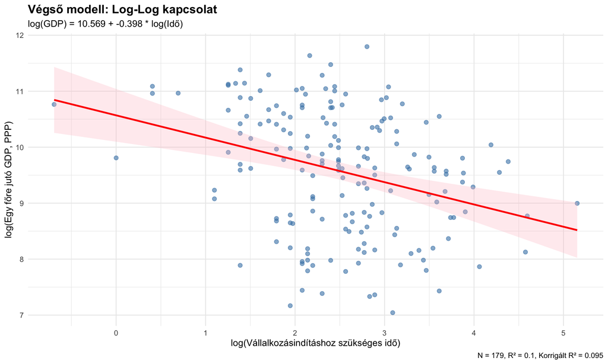

```r
# Végső modell vizualizációja
ggplot(data_robust, aes(x = log_time, y = log_gdp)) +
  geom_point(alpha = 0.6, size = 2, color = "steelblue") +
  geom_smooth(method = "lm", se = TRUE, color = "red", fill = "pink", alpha = 0.3) +
  labs(title = "Végső modell: Log-Log kapcsolat",
       subtitle = paste0("log(GDP) = ", round(coef(final_model)[1], 3),
                        " + ", round(coef(final_model)[2], 3), " * log(Idő)"),
       x = "log(Vállalkozásindításhoz szükséges idő)",
       y = "log(Egy főre jutó GDP, PPP)",
       caption = paste0("N = ", nrow(data_robust),
                       ", R² = ", round(summary_final$r.squared, 3),
                       ", Korrigált R² = ", round(summary_final$adj.r.squared, 3))) +
  theme_minimal() +
  theme(plot.title = element_text(face = "bold", size = 14),
        plot.subtitle = element_text(size = 11))
```

# 7. Eredmények értelmezése

## Modell specifikáció

A végső modellünk:

$$\log(\text{Egy főre jutó GDP}) = \beta_0
+ \beta_1 \log(\text{Vállalkozásindítási idő})$$

Ahol: - $\beta_0$ = 10.569 (Tengelymetszet) - $\beta_1$ = -0.3981 (Meredekség/Rugalmasság) - R² = 0.0997 - Korrigált R² = 0.0946 - N = 179 ország (2019 keresztmetszeti adatok)

## Statisztikai szignifikancia

```r
coef_estimate <- coef(final_model)[2]
coef_se <- summary_final$coefficients[2, 2]
coef_tstat <- summary_final$coefficients[2, 3]
coef_pval <- summary_final$coefficients[2, 4]

cat("Meredekség együttható (rugalmasság):", round(coef_estimate, 4), "\n")
```

```
## Meredekség együttható (rugalmasság): -0.3981
```

```r
cat("Standard hiba:", round(coef_se, 4), "\n")
```

```
## Standard hiba: 0.0899
```

```r
cat("t-statisztika:", round(coef_tstat, 4), "\n")
```

```
## t-statisztika: -4.4273
```

```r
cat("p-érték:", format.pval(coef_pval, digits = 4), "\n\n")
```

```
## p-érték: 1.666e-05
```

```r
if(coef_pval < 0.001) {
  cat("A kapcsolat statisztikailag erősen szignifikáns (p < 0.001).\n")
} else if(coef_pval < 0.01) {
  cat("A kapcsolat statisztikailag nagyon szignifikáns (p < 0.01).\n")
} else if(coef_pval < 0.05) {
  cat("A kapcsolat statisztikailag szignifikáns (p < 0.05).\n")
} else {
  cat("A kapcsolat nem szignifikáns a hagyományos szinteken.\n")
}
```

```
## A kapcsolat statisztikailag erősen szignifikáns (p < 0.001).
```

## Gazdasági értelmezés

**1. Rugalmassági értelmezés:**

A log-log modellben a meredekség együttható a rugalmasságot jelenti. A becsült -0.3981 együttható azt jelenti:

- A vállalkozásindításhoz szükséges idő **1%-os növekedése** körülbelül **-0.4%-os változással** jár az egy főre jutó GDP-ben.
- Mivel az együttható negatív, ez inverz kapcsolatot jelez.

**2. Gyakorlati értelmezés:**

```r
# Példa: Mi történik, ha a vállalkozásindítási idő 20%-kal csökken?
pct_change_time <- -20  # 20%-os csökkenés
pct_change_gdp <- pct_change_time * coef_estimate
cat("Ha a vállalkozásindítási idő 20%-kal csökken,\n")
```

```
## Ha a vállalkozásindítási idő 20%-kal csökken,
```

```r
cat("az egy főre jutó GDP várhatóan körülbelül",
    round(pct_change_gdp, 2), "%-kal változik\n\n")
```

```
## az egy főre jutó GDP várhatóan körülbelül 7.96 %-kal változik
```

```r
# Példa: Két hipotetikus ország összehasonlítása
time1 <- 10  # A ország: 10 nap
time2 <- 30  # B ország: 30 nap
ratio_time <- time2 / time1
expected_gdp_ratio <- ratio_time^coef_estimate
cat("Ha az A országban", time1, "napba telik vállalkozást indítani,\n")
```

```
## Ha az A országban 10 napba telik vállalkozást indítani,
```

```r
cat("a B országban pedig", time2, "napba,\n")
```

```
## a B országban pedig 30 napba,
```

```r
cat("a B ország egy főre jutó GDP-je várhatóan körülbelül",
    round((expected_gdp_ratio - 1) * 100, 1), "%-kal tér el az A országétól,\n")
```

```
## a B ország egy főre jutó GDP-je várhatóan körülbelül -35.4 %-kal tér el az A országétól,
```

```r
cat("egyebek változatlansága mellett.\n")
```

```
## egyebek változatlansága mellett.
```

**3. Modell illeszkedése:**

- Az R² = 0.1 azt jelzi, hogy a log(egy főre jutó GDP) varianciájának körülbelül 10%-át magyarázza a log(vállalkozásindítási idő).
- Bár ez értelmes kapcsolatot mutat, azt is jelzi, hogy sok más tényező is hozzájárul a GDP-különbségekhez az országok között.

**4. Funkcionális forma indoklása:**

A log-log specifikációt választottuk, mert:

1. **Elméleti**: A gazdasági kapcsolatok gyakran állandó rugalmasságot mutatnak, nem állandó meredekséget
2. **Statisztikai**: A log-log modell jó illeszkedést mutatott közelítőleg normális reziduálisokkal
3. **Gyakorlati**: Mindkét változó jobbra ferdült; a log transzformáció normalizálja az eloszlásokat
4. **Értelmezhetőség**: A rugalmassági értelmezés intuitív a szakpolitikai elemzéshez

**5. Befolyásos megfigyelések kezelése:**

3 azonosítottunk erősen problémás befolyásos megfigyelés(eke)t kombinált kritériumok alapján (magas Cook-távolság ÉS akár magas tőkeáttétel, akár szélsőséges reziduálisok). Ezeket eltávolítottuk a végső modellből, hogy robusztus következtetéseket biztosítsunk. A fennmaradó 179 ország stabil alapot biztosít a következtetésekhez.

# 8. Következtetések

## Szakpolitikai vonatkozások

A negatív kapcsolat azt sugallja, hogy a vállalkozásalapítás bürokratikus akadályainak csökkentése magasabb gazdasági prosperitással jár együtt. Azonban az okozati összefüggés nem állapítható meg ebből a keresztmetszeti elemzésből:

- A magasabb GDP-vel rendelkező országok több forrással rendelkezhetnek a vállalkozási bejegyzés egyszerűsítésére
- Mindkét változót közös tényezők hajthatják (intézmények, kormányzás stb.)
- Hosszanti elemzésre lenne szükség az okozati hatások megállapításához

## Javaslatok a jövőbeli elemzéshez

1. **Paneladatok elemzése**: Több év használata az időbeli országon belüli változások vizsgálatára és az országspecifikus fix hatások kontrollálására
2. **Kontrollváltozók bevonása**: Oktatás, infrastruktúra, intézmények, politikai stabilitás stb. hozzáadása
3. **Nemlineáris kapcsolatok**: Potenciális küszöbhatások vagy nem-monoton kapcsolatok vizsgálata
4. **Regionális heterogenitás**: Annak tesztelése, hogy a kapcsolat eltér-e a földrajzi régiók vagy jövedelmi csoportok között
5. **Instrumentális változók**: Az endogenitási problémák kezelése az okozati kapcsolatok jobb megállapításához
6. **Idősorok**: Annak vizsgálata, hogy a vállalkozási szabályozás változásai megelőzik-e a GDP változásait

**Elemzés befejezve: 2025-11-18**